# Growth Modeling

Tristan, Kyle

5/5/2021

# 1 Introduction

Population growth poses a challenge for many cities across the United States. Understanding where population growth will most likely occur is essential in understanding where to locate new development projects, where to locate public services, how to alter the zoning ordinance, and where urban growth boundaries should be located. Portland, Oregon is known for strict development regulations that concentrate the metropolitan region’s new development within urban growth boundaries. Within this study we explore where population and development will most likely grow in the Portland Metropolitan Area, and by how much.

The Portland Metropolitan Region consists of Clackamas County, Columbia County, Multnomah County, Washington County, Yamhill County, Clark County and Skamania County. Note that Clark County and Skamania County were excluded from the analysis since it is located in Washington State rather than Oregon. In the past few years, there has been talk about extending the metro lines regionally. For our analysis, we look at population projections in two different counties for the current scenario, and for the scenario where train lines are extended farther away from the city center.

## 1.1 Set-Up

```r
knitr::opts_chunk$set(echo = TRUE)
library(tidyverse)
library(sf)
library(raster)
library(knitr)
library(kableExtra)
library(tidycensus)
library(tigris)
library(FNN)
library(QuantPsyc)
library(caret)
library(yardstick)
library(pscl)
library(plotROC)
library(ggrepel)
library(pROC)
library(grid)
library(gridExtra)
library(viridis)
library(exactextractr)
library(igraph)

mapTheme <- function(base_size = 12) {
  theme(
    text = element_text( color = "black"),
    plot.title = element_text(size = 14,colour = "black"),
    plot.subtitle=element_text(face="italic"),
    plot.caption=element_text(hjust=0),
    axis.ticks = element_blank(),
    panel.background = element_blank(),axis.title = element_blank(),
    axis.text = element_blank(),
    axis.title.x = element_blank(),
    axis.title.y = element_blank(),
    panel.grid.minor = element_blank(),
    panel.border = element_rect(colour = "black", fill=NA, size=2)
  )
}

plotTheme <- function(base_size = 12) {
  theme(
    text = element_text( color = "black"),
    plot.title = element_text(size = 14,colour = "black"),
    plot.subtitle = element_text(face="italic"),
    plot.caption = element_text(hjust=0),
    axis.ticks = element_blank(),
    panel.background = element_blank(),
    panel.grid.major = element_line("grey80", size = 0.1),
    panel.grid.minor = element_blank(),
    panel.border = element_rect(colour = "black", fill=NA, size=2),
    strip.background = element_rect(fill = "grey80", color = "white"),
    strip.text = element_text(size=12),
    axis.title = element_text(size=12),
    axis.text = element_text(size=10),
    plot.background = element_blank(),
    legend.background = element_blank(),
    legend.title = element_text(colour = "black", face = "italic"),
    legend.text = element_text(colour = "black", face = "italic"),
    strip.text.x = element_text(size = 14)
  )
}

palette2 <- c("#41b6c4","#253494")
palette4 <- c("#a1dab4","#41b6c4","#2c7fb8","#253494")
palette5 <- c("#ffffcc","#a1dab4","#41b6c4","#2c7fb8","#253494")
palette10 <- c("#f7fcf0","#e0f3db","#ccebc5","#a8ddb5","#7bccc4",
               "#4eb3d3","#2b8cbe","#0868ac","#084081","#f7fcf0")
root.dir = "https://raw.githubusercontent.com/urbanSpatial/Public-Policy-Analytics-Landing/master/DATA/"
source("https://raw.githubusercontent.com/urbanSpatial/Public-Policy-Analytics-Landing/master/functions.r")
```

### 1.1.1 Functions

```r
#this function converts a column in to quintiles. It is used for mapping.
quintileBreaks <- function(df,variable) {
    as.character(quantile(df[[variable]],
                          c(.01,.2,.4,.6,.8),na.rm=T))
}

#This function can be used to convert a polygon sf to centroids xy coords.
xyC <- function(aPolygonSF) {
  as.data.frame(
    cbind(x=st_coordinates(st_centroid(aPolygonSF))[,1],
          y=st_coordinates(st_centroid(aPolygonSF))[,2]))
}

#this function convert a raster to a data frame so it can be plotted in ggplot
rast <- function(inRaster) {
  data.frame(
    xyFromCell(inRaster, 1:ncell(inRaster)),
    value = getValues(inRaster)) }
```

### 1.1.2 Reading in the Boundary and Land Cover Δ (LCΔ) Data

Here we plot regions that changed to development over our 10 year study period.

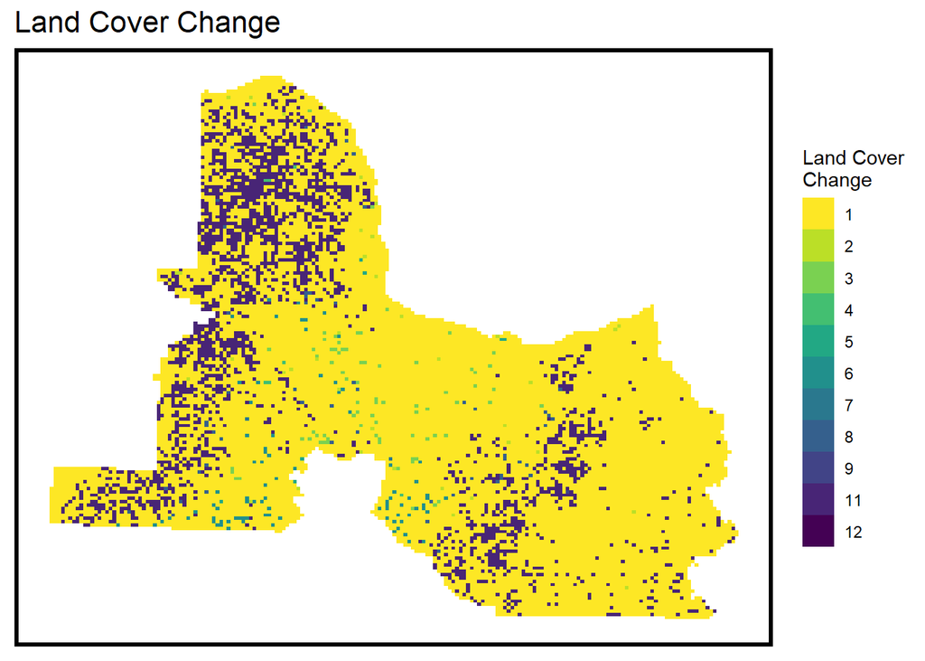

```r
WashingtonB<- st_read("https://opendata.arcgis.com/datasets/12712f465fc44fb58328c6e0255ca27e_0.geojson")%>% st_transform('ESRI:102326')%>%
  rename(Name = COUNTY_NM)%>%
  dplyr::select(Name, geometry) %>%
  filter(Name == "Clark County" | Name == "Skamania County")

OregonB <-
  st_read("https://opendata.arcgis.com/datasets/65432a0067f949dd99f3ad0f51f11667_9.geojson") %>%
  st_transform('ESRI:102326')%>%
  rename(Name = COUNTY)%>%
  dplyr::select(Name, geometry)%>%
  filter(Name == "Clackamas" | Name == "Columbia" | Name == "Multnomah" | Name == "Washington" | Name == "Yamhill")

PortlandMetro <- rbind(WashingtonB, OregonB)

lc_2001 = raster("C:/Users/Tristan/Desktop/PennSpring2021/CPLN675/FINAL/NLCD2001_portlandmetro_300m.tif")
#%>%projectRaster("ESRI:102326") #for some reason this doesn't work

lc_2011 = raster("C:/Users/Tristan/Desktop/PennSpring2021/CPLN675/FINAL/NLCD2011_portlandmetro_300m.tif")
#%>%projectRaster('ESRI:102326')

lc_change = raster("C:/Users/Tristan/Desktop/PennSpring2021/CPLN675/FINAL/Kyle-and-Tristan-Growth-Modeling-main/Data/PortlandO.tif")
#%>%projectRaster('ESRI:102326')

ggplot() +
  geom_raster(data=rast(lc_change) %>% na.omit %>% filter(value > 0 & value < 200),
              aes(x,y,fill=as.factor(value))) +
  scale_fill_viridis(direction = -1, discrete=TRUE, name ="Land Cover\nChange") +
  labs(title = "Land Cover Change") +
  mapTheme()
```

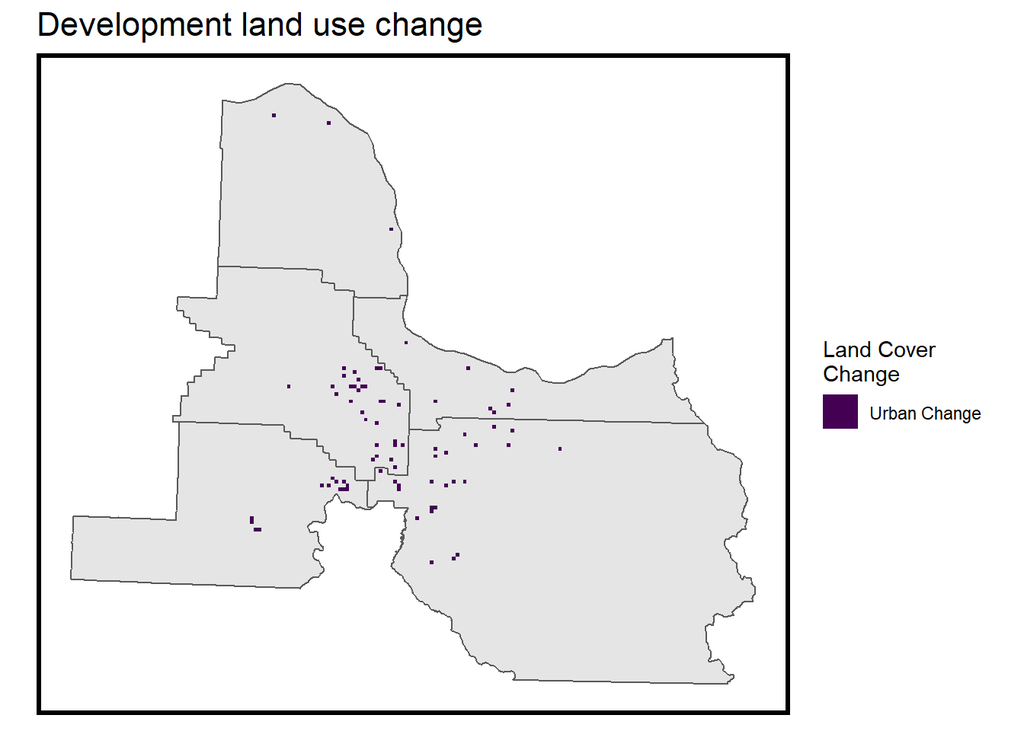

```r
m <- c(0, 2, 0,  3, 3, 1,  3,
        Inf,  0)
m <- matrix(m, ncol=3, byrow = T)

lc_change2 <-
  reclassify(lc_change,m)

lc_change2[lc_change2 < 1] <- NA

freq(lc_change2)

names(lc_change2) <- "lc_change"

ggplot() +
geom_sf(data = OregonB) +
  geom_tile(data=rast(lc_change2) %>% na.omit %>%
                mutate(Class = "Urban Change") %>% filter(value == 3),
              aes(x,y,fill=as.factor(Class))) +
  scale_fill_viridis(discrete=TRUE, name ="Land Cover\nChange") +
  labs(title="Development land use change") +
  mapTheme()
```

# 2 Data Wrangling and Feature Engineering

## 2.1 Portland Fishnet and Associated LCΔ

Development can be treated like a continuous surface; it is a land cover type that varies in intensity over space much like vegetation density. Creating grids allow us to model development over space.

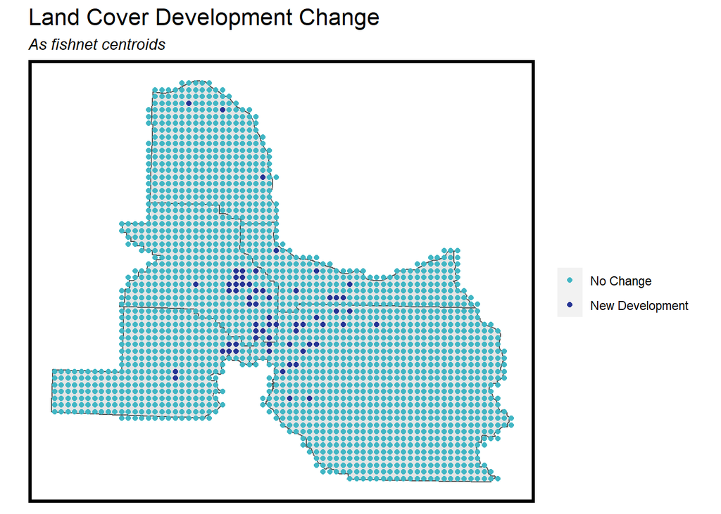

```r
PortlandOMSA_fishnet <-
  st_make_grid(OregonB, 2460.63) %>% # 984.252 ft = 300m    2952.76 = 900m 2640.64ft = 750m
  st_sf()%>%
  mutate(ID = seq.int(nrow(.)))

PortlandOMSA_fishnet <-
  PortlandOMSA_fishnet[OregonB,]

# ggplot() +
#   geom_sf(data=PortlandOMSA_fishnet) +
#   labs(title="Fishnet, 900 m resolution") +
#   mapTheme()

changePoints <-
  rasterToPoints(lc_change2) %>%
  as.data.frame() %>%
  st_as_sf(coords = c("x", "y"), crs = st_crs(PortlandOMSA_fishnet))

FinalFishnet <-
  aggregate(changePoints, PortlandOMSA_fishnet, sum) %>%
  mutate(lc_change = ifelse(is.na(lc_change),0,1),
         lc_change = as.factor(lc_change))%>%
  mutate(ID = seq.int(nrow(.)))

ggplot() +
  geom_sf(data=OregonB) +
  geom_point(data=FinalFishnet,
             aes(x=xyC(FinalFishnet)$x, y=xyC(FinalFishnet)$y, colour=lc_change)) +
  scale_colour_manual(values = palette2,
                      labels=c("No Change","New Development"),
                      name = "") +
  labs(title = "Land Cover Development Change", subtitle = "As fishnet centroids") +
  mapTheme()
```

## 2.2 OSM Building Counts to Grid

This section finds building count within each of the grid cells.

```r
buildings<- st_read("C:/Users/Tristan/Desktop/PennSpring2021/CPLN675/FINAL/osmbuildings.shp")%>% st_transform('ESRI:102326')

# find points within polygons
PortlandOMSA_fishnet_buildings <- st_join(buildings, PortlandOMSA_fishnet, join = st_within)

# count of buildings per grid
PortlandOMSA_fishnet_buildings <- count(as_tibble(PortlandOMSA_fishnet_buildings), ID)
PortlandOMSA_fishnet <- left_join(PortlandOMSA_fishnet, PortlandOMSA_fishnet_buildings)
PortlandOMSA_fishnet$buildingcount <- as.numeric(PortlandOMSA_fishnet$n)


# ggplot() +
#   geom_sf(data = PortlandOMSA_fishnet, aes(fill = q5(n)))+
#    scale_fill_manual(values = palette10,
#                     labels = qBr(PortlandOMSA_fishnet, "BuildingCount"),
#                     name = "Percent Impervious")+
#   labs(title = "Number of Buildings in each Grid Cell")+
#   theme(legend.position = "bottom")+
#   theme(plot.title = element_text(hjust = 0.5))+mapTheme()
```

## 2.3 Census Data

This section imports population data from the ACS census in 2010 and 2019 and relates those values to the grid.

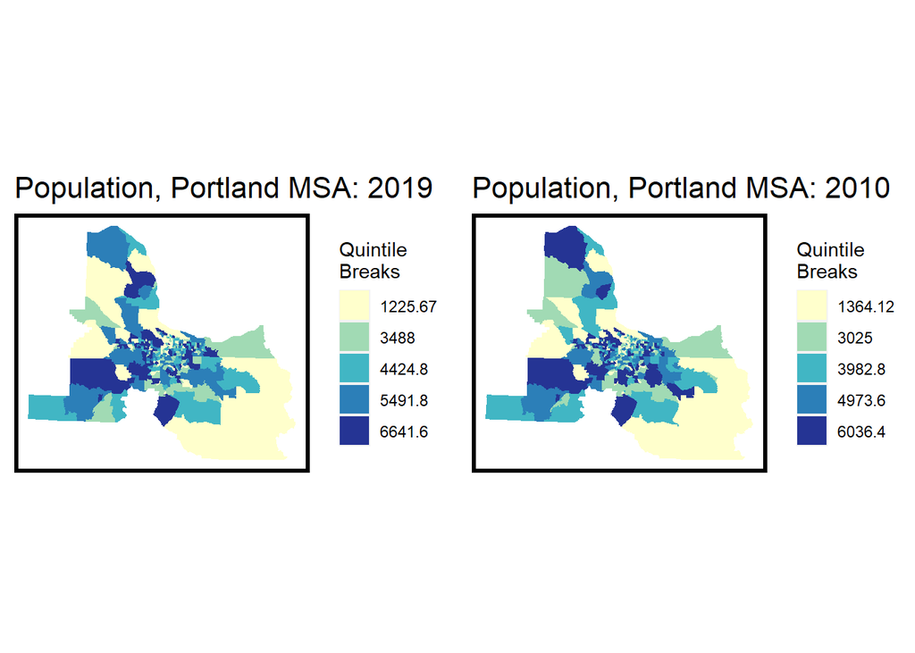

```r
census_api_key("d9ebfd04caa0138647fbacd94c657cdecbf705e9", install = FALSE, overwrite = TRUE)

options(tigris_use_cache = TRUE)

# 5 year ACS not available for 2000-2005, we chose a window
PortlandPop10 <-
 get_acs(geography = "tract", variables = "B01001_001", year = 2010,
                              state = 41, geometry = TRUE,
                              county=c(005, 009, 051, 067, 071)) %>%
  st_transform(st_crs(PortlandOMSA_fishnet))


PortlandPop19<-
   get_acs(geography = "tract", variables = "B01001_001", year = 2019,
                              state = 41, geometry = TRUE,
                              county=c(005, 009, 051, 067, 071)) %>%
  st_transform(st_crs(PortlandOMSA_fishnet))

# st_write(PortlandPop10, "C:/Users/Tristan/Desktop/PennSpring2021/CPLN675/FINAL/PortlandPop10.geojson")
# st_write(PortlandPop19, "C:/Users/Tristan/Desktop/PennSpring2021/CPLN675/FINAL/PortlandPop19.geojson")

grid.arrange(
ggplot() +
  geom_sf(data = PortlandPop19, aes(fill=factor(ntile(estimate,5))), colour=NA) +
  scale_fill_manual(values = palette5,
                    labels=quintileBreaks(PortlandPop19,"estimate"),
                   name="Quintile\nBreaks") +
  labs(title="Population, Portland MSA: 2019") +
  mapTheme(),

ggplot() +
  geom_sf(data = PortlandPop10, aes(fill=factor(ntile(estimate,5))), colour=NA) +
  scale_fill_manual(values = palette5,
                    labels=quintileBreaks(PortlandPop10,"estimate"),
                   name="Quintile\nBreaks") +
  labs(title="Population, Portland MSA: 2010") +
  mapTheme(), ncol=2)
```

## 2.4 Population Interpolation

Population change is found between 2010 and 2019, interpolated, and then related to the grids.

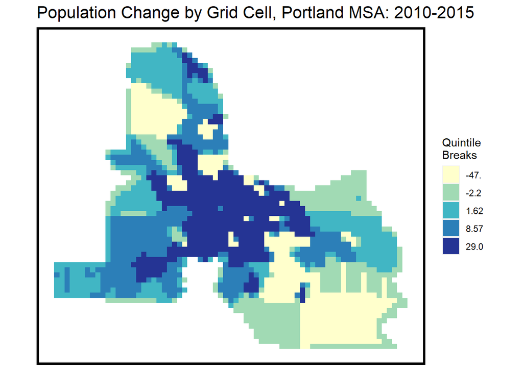

```r
PortlandOMSA_fishnet <-
  PortlandOMSA_fishnet %>%
  dplyr::select(ID)

fishnetPopulation10 <-
  st_interpolate_aw(PortlandPop10["estimate"],PortlandOMSA_fishnet, extensive=TRUE) %>%
  as.data.frame(.) %>%
  left_join(PortlandOMSA_fishnet, ., by=c("ID"='Group.1')) %>%
  mutate(pop_2010 = replace_na(estimate,0)) %>%
  dplyr::select(pop_2010, ID)

fishnetPopulation19 <-
  st_interpolate_aw(PortlandPop19["estimate"],PortlandOMSA_fishnet, extensive=TRUE) %>%
  as.data.frame(.) %>%
  left_join(PortlandOMSA_fishnet, ., by=c("ID"='Group.1')) %>%
  mutate(pop_2019 = replace_na(estimate,0)) %>%
  dplyr::select(pop_2019, ID)

fishnetPopulation <-
  cbind(fishnetPopulation10,fishnetPopulation19) %>%
  dplyr::select(pop_2010,pop_2019, ID) %>%
  mutate(pop_Change = pop_2019 - pop_2010)

FinalFishnet <- left_join(FinalFishnet, st_drop_geometry(fishnetPopulation))

ggplot() +
  geom_sf(data=FinalFishnet, aes(fill=factor(ntile(pop_Change,5))),colour=NA) +
  scale_fill_manual(values = palette5,
                   labels=substr(quintileBreaks(fishnetPopulation,"pop_Change"),1,4),
                   name="Quintile\nBreaks") +
  labs(title="Population Change by Grid Cell, Portland MSA: 2010-2015") +
  mapTheme()
```

## 2.5 Highways

Distance to highways will impact development and population changes; people may prefer to locate near quick transportation such as highways.

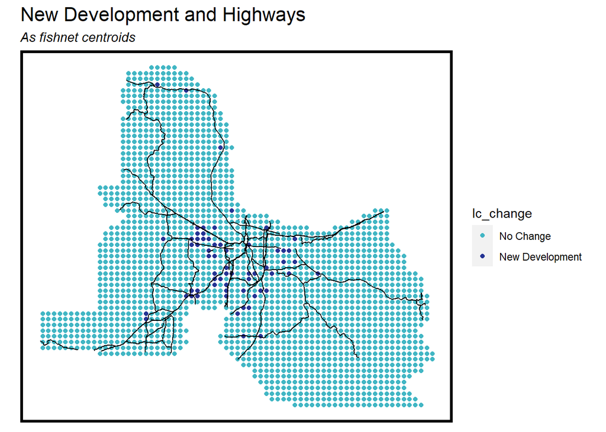

```r
HW <-
  st_read("C:/Users/Tristan/Desktop/PennSpring2021/CPLN675/FINAL/Kyle-and-Tristan-Growth-Modeling-main/Data/hw.shp") %>%
  st_zm()%>%
  st_transform(st_crs(OregonB)) %>%
  st_intersection(OregonB)


emptyRaster <- lc_change
emptyRaster[] <- NA

highway_raster <-
  as(HW,'Spatial') %>%
  rasterize(.,emptyRaster)

highway_raster_distance <- distance(highway_raster)
names(highway_raster_distance) <- "distance_highways"

highwayPoints <-
  rasterToPoints(highway_raster_distance) %>%
  as.data.frame() %>%
  st_as_sf(coords = c("x", "y"), crs = st_crs(PortlandOMSA_fishnet))

highwayPoints_fishnet <-
  aggregate(highwayPoints, PortlandOMSA_fishnet, mean) %>%
  mutate(distance_highways = ifelse(is.na(distance_highways),0,distance_highways))


fishnet <- highwayPoints_fishnet

ggplot() +
  geom_point(data=FinalFishnet,
             aes(x=xyC(FinalFishnet)[,1], y=xyC(fishnet)[,2],colour=lc_change),size=1.5) +
  geom_sf(data=HW) +
  scale_colour_manual(values = palette2,
                      labels=c("No Change","New Development")) +
  labs(title = "New Development and Highways",
       subtitle = "As fishnet centroids") +
  mapTheme()
```

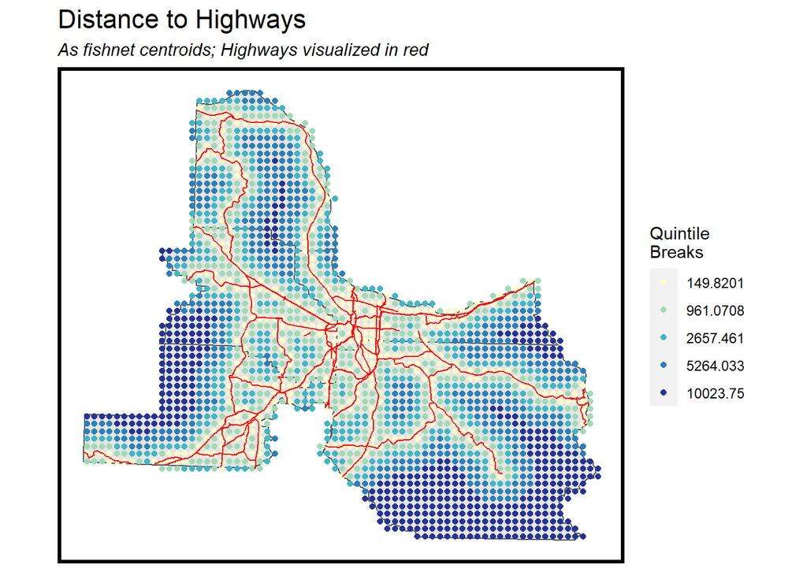

```r
ggplot() +
  geom_sf(data=OregonB) +
  geom_point(data=highwayPoints_fishnet, aes(x=xyC(highwayPoints_fishnet)[,1],
                                             y=xyC(highwayPoints_fishnet)[,2],
                 colour=factor(ntile(distance_highways,5))),size=1.5) +
  scale_colour_manual(values = palette5,
                      labels=substr(quintileBreaks(highwayPoints_fishnet,"distance_highways"),1,8),
                      name="Quintile\nBreaks") +
  geom_sf(data=HW, colour = "red") +
  labs(title = "Distance to Highways",
       subtitle = "As fishnet centroids; Highways visualized in red") +
  mapTheme()
```

## 2.6 Urban Growth Boundary

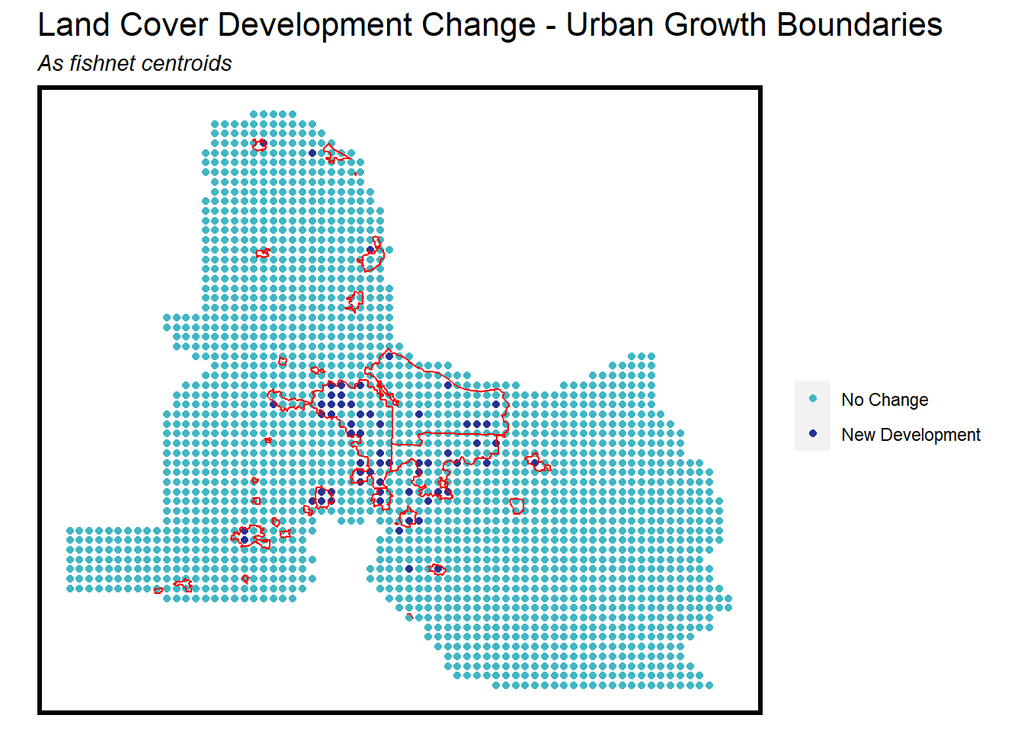

```r
ugb <- st_read("C:/Users/Tristan/Desktop/PennSpring2021/CPLN675/FINAL/Kyle-and-Tristan-Growth-Modeling-main/Data/UGB.geojson")%>%
  st_transform(st_crs(OregonB))%>%
  st_make_valid() %>%
  st_intersection(OregonB)

ggplot() +
  geom_point(data=FinalFishnet,
             aes(x=xyC(FinalFishnet)$x, y=xyC(FinalFishnet)$y, colour=lc_change)) +
  scale_colour_manual(values = palette2,
                      labels=c("No Change","New Development"),
                      name = "") +
  labs(title = "Land Cover Development Change - Urban Growth Boundaries", subtitle = "As fishnet centroids") +
  geom_sf(data = ugb, fill = NA, colour = "red")+
  mapTheme()
```

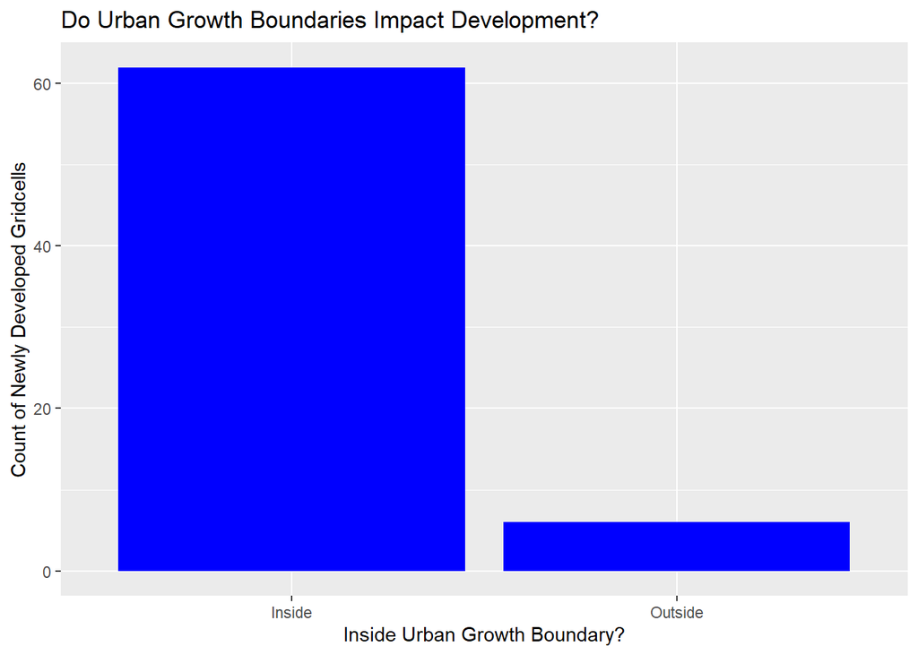

```r
fishnetDev <-
  FinalFishnet%>%
  filter(lc_change == 1)%>%
  mutate(ID = seq.int(nrow(.)))

UGBdev <-
  fishnetDev %>%
  st_intersection(ugb)%>%
  mutate(In_UGB = "Inside")%>%
  st_drop_geometry()%>%
  left_join(fishnetDev, .)%>%
  mutate(In_UGB = replace_na(In_UGB, "Outside"))

ggplot(UGBdev, aes(In_UGB)) +
  geom_bar(fill = "blue") +
  xlab("Inside Urban Growth Boundary?")+
  ylab("Count of Newly Developed Gridcells")+
  labs(title = "Do Urban Growth Boundaries Impact Development?")
```

```r
fishnetUGB <-
  FinalFishnet%>%
  mutate(ID = seq.int(nrow(.)))

fishnetUGBAll <-
  fishnetUGB %>%
  st_centroid()%>%
  st_intersection(ugb)%>%
  mutate(In_UGB = "Inside")%>%
  st_drop_geometry()%>%
  left_join(fishnetUGB, .)%>%
  mutate(In_UGB = replace_na(In_UGB, "Outside"))%>%
  dplyr::select(In_UGB, geometry)
```

## 2.7 Spatial Lag of Development

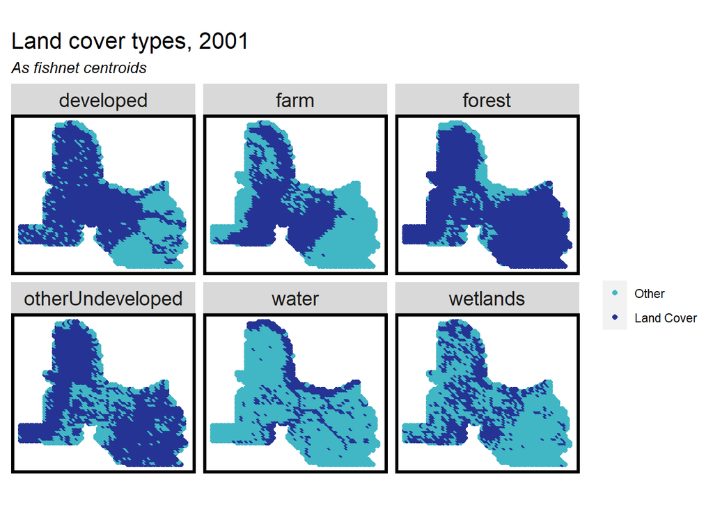

```r
#reload LC data from Kyle, version is clipped
lc_2001 = raster("C:/Users/Tristan/Desktop/PennSpring2021/CPLN675/FINAL/github2/Kyle-and-Tristan-Growth-Modeling-main/Data/lc2001.tif")
#%>%projectRaster("ESRI:102326") #for some reason this doesn't work

lc_2011 = raster("C:/Users/Tristan/Desktop/PennSpring2021/CPLN675/FINAL/github2/Kyle-and-Tristan-Growth-Modeling-main/Data/lc2011.tif")
#%>%projectRaster('ESRI:102326')


nn_function <- function(measureFrom,measureTo,k) {
  #convert the sf layers to matrices
  measureFrom_Matrix <-
    as.matrix(measureFrom)
  measureTo_Matrix <-
    as.matrix(measureTo)
  nn <-
    get.knnx(measureTo, measureFrom, k)$nn.dist
    output <-
    as.data.frame(nn) %>%
    rownames_to_column(var = "thisPoint") %>%
    gather(points, point_distance, V1:ncol(.)) %>%
    arrange(as.numeric(thisPoint)) %>%
    group_by(thisPoint) %>%
    summarize(pointDistance = mean(point_distance)) %>%
    arrange(as.numeric(thisPoint)) %>%
    dplyr::select(-thisPoint) %>%
    pull()

  return(output)
}


PortlandOMSA_fishnet <- st_as_sf(PortlandOMSA_fishnet)

PortlandOMSA_fishnet$lc2001 <- exactextractr::exact_extract(lc_2001, PortlandOMSA_fishnet, 'mode')

PortlandOMSA_fishnet$lc2011 <- exactextractr::exact_extract(lc_2011, PortlandOMSA_fishnet, 'mode')

developed <- lc_2001 == 21 | lc_2001 == 22 | lc_2001 == 23 | lc_2001 == 24
forest <- lc_2001 == 41 | lc_2001 == 42 | lc_2001 == 43
farm <- lc_2001 == 81 | lc_2001 == 82
wetlands <- lc_2001 == 90 | lc_2001 == 95
otherUndeveloped <- lc_2001 == 52 | lc_2001 == 71 | lc_2001 == 31
water <- lc_2001 == 11

names(developed) <- "developed"
names(forest) <- "forest"
names(farm) <- "farm"
names(wetlands) <- "wetlands"
names(otherUndeveloped) <- "otherUndeveloped"
names(water) <- "water"


aggregateRaster <- function(inputRasterList, theFishnet) {
  #create an empty fishnet with the same dimensions as the input fishnet
  theseFishnets <- theFishnet %>% dplyr::select()
  #for each raster in the raster list
  for (i in inputRasterList) {
  #create a variable name corresponding to the ith raster
  varName <- names(i)
  #convert raster to points as an sf
    thesePoints <-
      rasterToPoints(i) %>%
      as.data.frame() %>%
      st_as_sf(coords = c("x", "y"), crs = st_crs(theFishnet)) %>%
      filter(.[[1]] == 1)
  #aggregate to the fishnet
    thisFishnet <-
      aggregate(thesePoints, theFishnet, length) %>%
      mutate(!!varName := ifelse(is.na(.[[1]]),0,1))
  #add to the larger fishnet
    theseFishnets <- cbind(theseFishnets,thisFishnet)
  }
  #output all aggregates as one large fishnet
   return(theseFishnets)
  }

theRasterList <- c(developed,forest,farm,wetlands,otherUndeveloped,water)

aggregatedRasters <-
  aggregateRaster(theRasterList, PortlandOMSA_fishnet) %>%
  dplyr::select(developed,forest,farm,wetlands,otherUndeveloped,water) %>%
  mutate_if(is.numeric,as.factor)

aggregatedRasters %>%
  gather(var,value,developed:water) %>%
  st_cast("POLYGON") %>%    #just to make sure no weird geometries slipped in
  mutate(X = xyC(.)$x,
         Y = xyC(.)$y) %>%
  ggplot() +
    geom_sf(data=PortlandOMSA_fishnet) +
    geom_point(aes(X,Y, colour=as.factor(value))) +
    facet_wrap(~var) +
    scale_colour_manual(values = palette2,
                        labels=c("Other","Land Cover"),
                        name = "") +
    labs(title = "Land cover types, 2001",
         subtitle = "As fishnet centroids") +
   mapTheme()
```

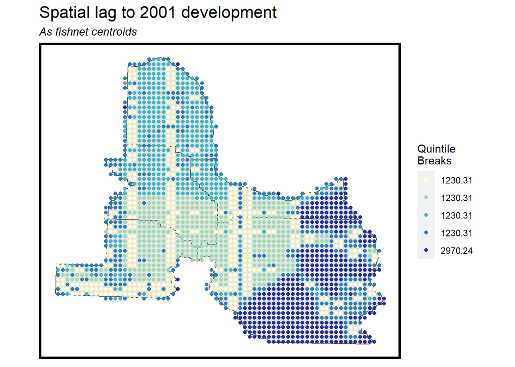

```r
aggregatedRasters$lc2001 <- exactextractr::exact_extract(lc_2001, aggregatedRasters, 'mode')

aggregatedRasters$lc2011 <- exactextractr::exact_extract(lc_2011, aggregatedRasters, 'mode')

aggregatedRasters$lagDevelopment <-
    nn_function(xyC(aggregatedRasters),
                xyC(filter(aggregatedRasters,developed==1)), 2)

ggplot() +
  geom_sf(data=OregonB) +
  geom_point(data=aggregatedRasters,
             aes(x=xyC(aggregatedRasters)[,1], y=xyC(aggregatedRasters)[,2],
                 colour=factor(ntile(lagDevelopment,5))), size=1.5) +
  scale_colour_manual(values = palette5,
                     labels=substr(quintileBreaks(aggregatedRasters,"lagDevelopment"),1,7),
                     name="Quintile\nBreaks") +
  labs(title = "Spatial lag to 2001 development",
       subtitle = "As fishnet centroids") +
  mapTheme()
```

## 2.8 Railways

Distance to railways may impact and population change, people prefer easy access to transit.

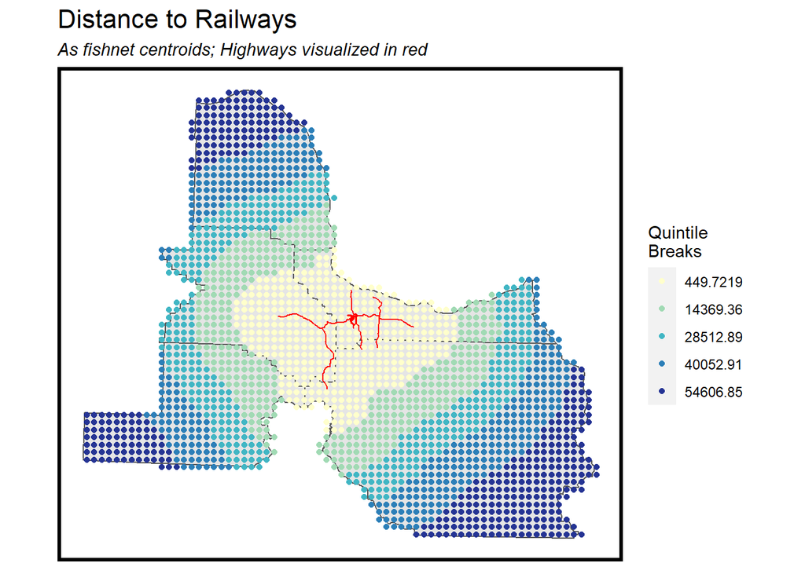

```r
rail <- st_read("C:/Users/Tristan/Desktop/PennSpring2021/CPLN675/FINAL/New folder/tm_rail_lines.shp")%>%
  st_transform(st_crs(OregonB)) %>%
  st_intersection(OregonB)


emptyRaster <- lc_change
emptyRaster[] <- NA

rail_raster <-
  as(rail,'Spatial') %>%
  rasterize(.,emptyRaster)

railway_raster_distance <- distance(rail_raster)
names(railway_raster_distance) <- "distance_railways"

railwayPoints <-
  rasterToPoints(railway_raster_distance) %>%
  as.data.frame() %>%
  st_as_sf(coords = c("x", "y"), crs = st_crs(PortlandOMSA_fishnet))

railwayPoints_fishnet <-
  aggregate(railwayPoints, PortlandOMSA_fishnet, mean) %>%
  mutate(distance_railways = ifelse(is.na(distance_railways),0,distance_railways))



ggplot() +
  geom_sf(data=OregonB) +
  geom_point(data=railwayPoints_fishnet, aes(x=xyC(railwayPoints_fishnet)[,1],
                                             y=xyC(railwayPoints_fishnet)[,2],
                 colour=factor(ntile(distance_railways,5))),size=1.5) +
  scale_colour_manual(values = palette5,
                      labels=substr(quintileBreaks(railwayPoints_fishnet,"distance_railways"),1,8),
                      name="Quintile\nBreaks") +
  geom_sf(data=rail, colour = "red") +
  labs(title = "Distance to Railways",
       subtitle = "As fishnet centroids; Highways visualized in red") +
  mapTheme()
```

```r
options(tigris_class = "sf")

studyAreaCounties <-
  counties("Oregon") %>%
  st_transform(st_crs(PortlandMetro)) %>%
  dplyr::select(NAME) %>%
  .[st_buffer(PortlandMetro,-1000), , op=st_intersects]
```

## 2.9 Development Scenario Regional Railroad Line

This feature is not part of our initial development model.

This feature is used in the forecast development scenario; a fictional large-scale rail project’s impact on demand for development in nearby areas. Demand and population are forecasted in two counties where this fictional rail project runs through. Land for development is allocated by the sensitivity of different land types. Forest and wetlands are considered high value land covers that cannot be developed.

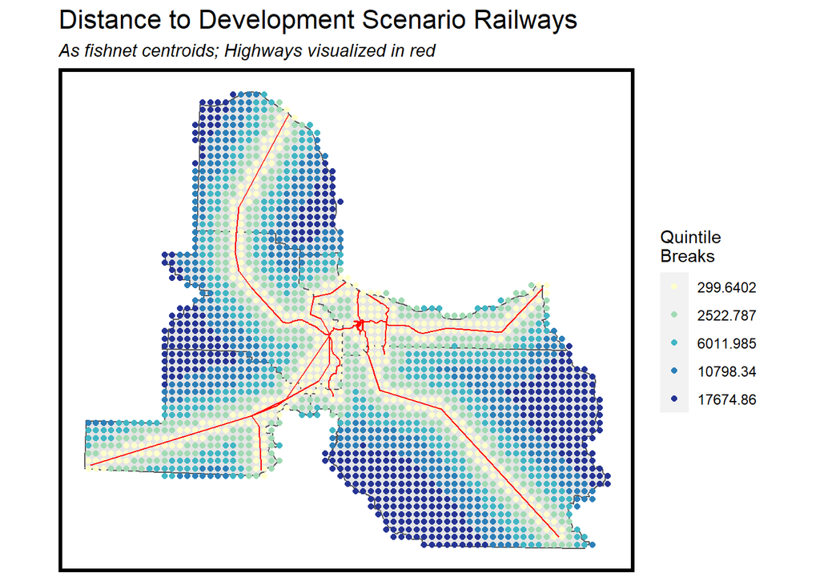

```r
fakerail <- st_read("C:/Users/Tristan/Desktop/PennSpring2021/CPLN675/FINAL/Kyle-and-Tristan-Growth-Modeling-main/Data/tm_rail_lines.shp")%>%
  st_transform(st_crs(OregonB)) %>%
  st_intersection(OregonB)


emptyRaster <- lc_change
emptyRaster[] <- NA

fakerail_raster <-
  as(fakerail,'Spatial') %>%
  rasterize(.,emptyRaster)

fakerailway_raster_distance <- distance(fakerail_raster)
names(fakerailway_raster_distance) <- "distance_fakerailways"

fakerailwayPoints <-
  rasterToPoints(fakerailway_raster_distance) %>%
  as.data.frame() %>%
  st_as_sf(coords = c("x", "y"), crs = st_crs(PortlandOMSA_fishnet))

fakerailwayPoints_fishnet <-
  aggregate(fakerailwayPoints, PortlandOMSA_fishnet, mean) %>%
  mutate(distance_fakerailways = ifelse(is.na(distance_fakerailways),0,distance_fakerailways))



ggplot() +
  geom_sf(data=OregonB) +
  geom_point(data=fakerailwayPoints_fishnet, aes(x=xyC(fakerailwayPoints_fishnet)[,1],
                                             y=xyC(fakerailwayPoints_fishnet)[,2],
                 colour=factor(ntile(distance_fakerailways,5))),size=1.5) +
  scale_colour_manual(values = palette5,
                      labels=substr(quintileBreaks(fakerailwayPoints_fishnet,"distance_fakerailways"),1,8),
                      name="Quintile\nBreaks") +
  geom_sf(data=fakerail, colour = "red") +
  labs(title = "Distance to Development Scenario Railways",
       subtitle = "As fishnet centroids; Highways visualized in red") +
  mapTheme()
```

```r
dat <-
  cbind(
    PortlandOMSA_fishnet, FinalFishnet, highwayPoints_fishnet, fishnetPopulation, fishnetUGBAll, aggregatedRasters, railwayPoints_fishnet, fakerailwayPoints_fishnet) %>%
  st_join(studyAreaCounties) %>%
  mutate(developed == as.numeric(developed), lc_change == as.numeric(lc_change))%>%
  mutate(developed10 = ifelse(lc_change == 1 & developed == 1, 0, developed)) %>%
  filter(water == 0) %>%
   st_join(OregonB) %>%
  st_join(studyAreaCounties)
```

# 3 Exploratory Analysis

## 3.1 Land Cover

Proximity to a highway increases development, as evidenced by the bar chart; new development tends to be closer to the highway than undeveloped grids.

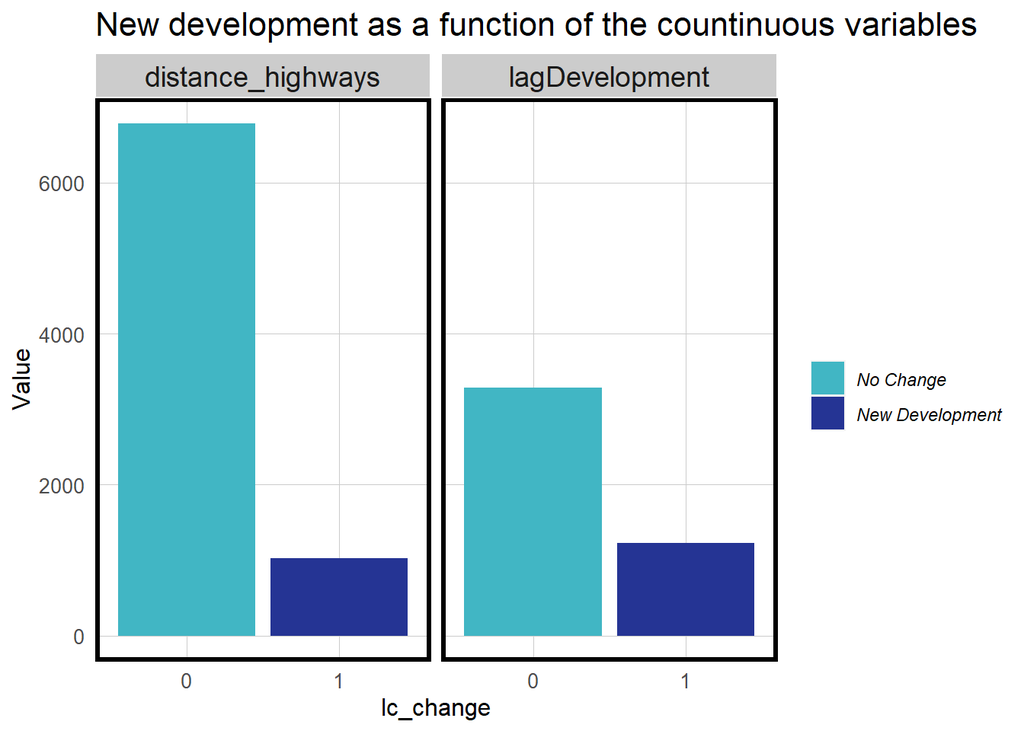

```r
dat %>%
  dplyr::select(distance_highways,lagDevelopment, lc_change) %>%
  gather(Variable, Value, -lc_change, -geometry) %>%
  ggplot(., aes(lc_change, Value, fill=lc_change)) +
    geom_bar(position = "dodge", stat = "summary", fun.y = "mean") +
    facet_wrap(~Variable) +
    scale_fill_manual(values = palette2,
                      labels=c("No Change","New Development"),
                      name="") +
    labs(title="New development as a function of the countinuous variables") +
    plotTheme()
```

## 3.2 Population

Greater population change is associated with new development.

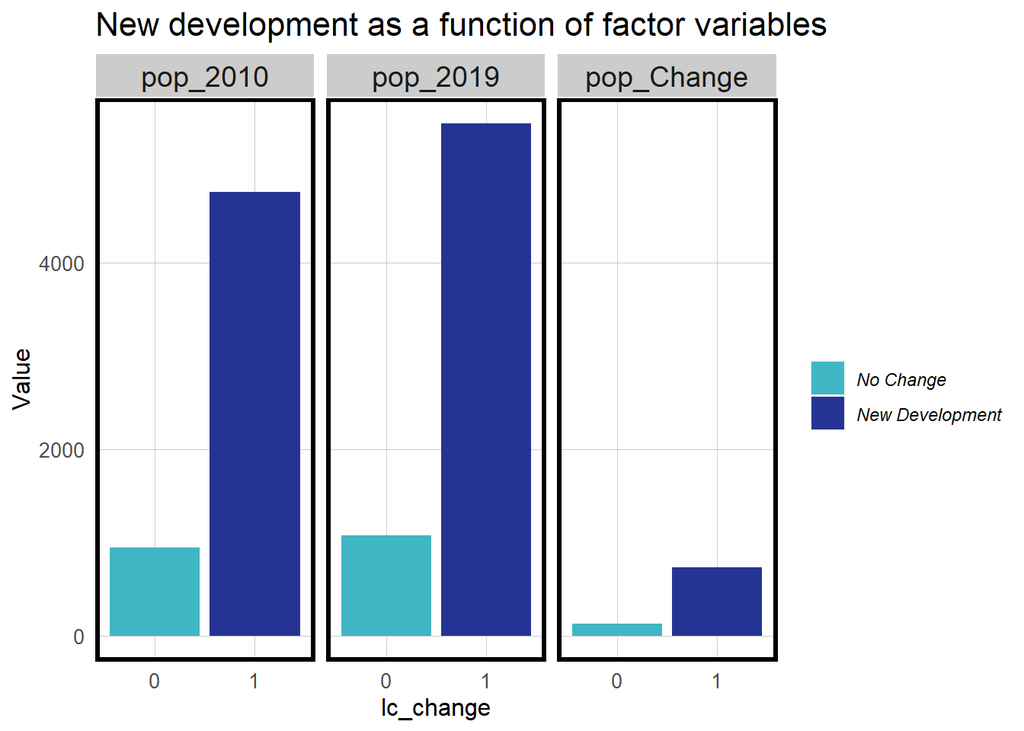

```r
dat %>%
  dplyr::select(pop_2010,pop_2019,pop_Change,lc_change) %>%
  gather(Variable, Value, -lc_change, -geometry) %>%
  ggplot(., aes(lc_change, Value, fill=lc_change)) +
    geom_bar(position = "dodge", stat = "summary", fun.y = "mean") +
    facet_wrap(~Variable) +
    scale_fill_manual(values = palette2,
                      labels=c("No Change","New Development"),
                      name="") +
    labs(title="New development as a function of factor variables") +
    plotTheme()
```

# 4 Model

## 4.1 Predicting for 2010

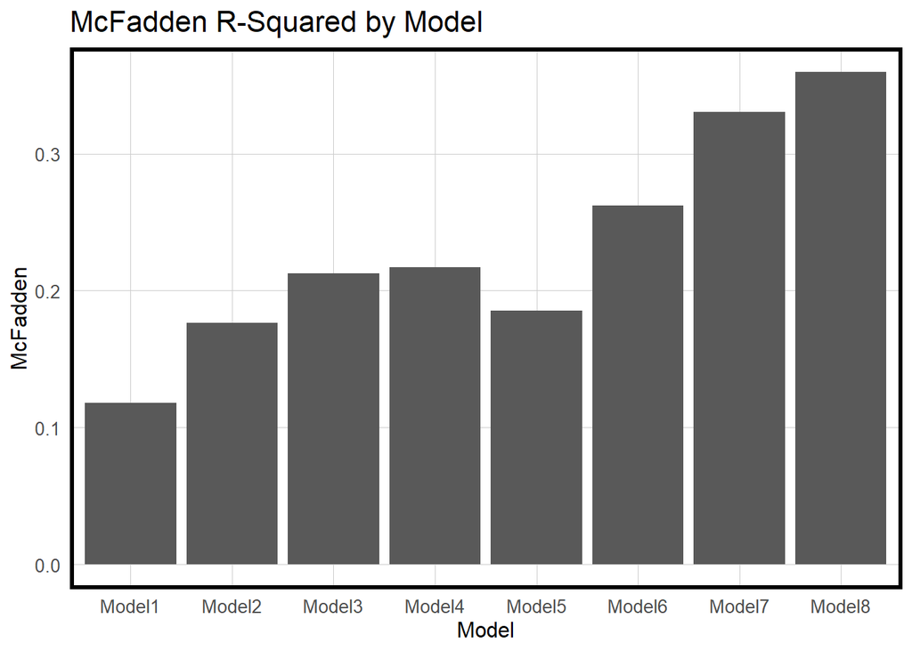

```r
set.seed(3456)
trainIndex <-
  createDataPartition(dat$developed, p = .50,
                                  list = FALSE,
                                  times = 1)
datTrain <- dat[ trainIndex,]
datTest  <- dat[-trainIndex,]

nrow(dat)


Model1 <- glm(lc_change ~ wetlands + forest  + farm + otherUndeveloped,
              family="binomial"(link="logit"), data = datTrain)

Model2 <- glm(lc_change ~ wetlands + forest  + farm + otherUndeveloped + lagDevelopment,
              family="binomial"(link="logit"), data = datTrain)

Model3 <- glm(lc_change ~ wetlands + forest  + farm + otherUndeveloped + lagDevelopment + pop_2010,
              family="binomial"(link="logit"), data = datTrain)

Model4 <- glm(lc_change ~ wetlands + forest  + farm + otherUndeveloped + lagDevelopment + pop_2010 + pop_2019,
              family="binomial"(link="logit"), data = datTrain)

Model5 <- glm(lc_change ~ wetlands + forest  + farm + otherUndeveloped + lagDevelopment + pop_Change,
              family="binomial"(link="logit"), data = datTrain)

Model6 <- glm(lc_change ~ wetlands + forest  + farm + otherUndeveloped + lagDevelopment + pop_Change + distance_highways,
              family="binomial"(link="logit"), data = datTrain)

Model7 <- glm(lc_change ~ wetlands + forest  + farm + otherUndeveloped + lagDevelopment + pop_Change + distance_highways + In_UGB,
              family="binomial"(link="logit"), data = datTrain)

#building count lowers accuracy of model significantly

#master model
Model8 <- glm(lc_change ~ wetlands + forest  + farm + otherUndeveloped  + pop_Change + distance_highways + In_UGB + distance_railways,
              family="binomial"(link="logit"), data = datTrain)

Model10 <- glm(lc_change ~ wetlands + forest  + farm + otherUndeveloped + pop_Change + distance_highways + distance_fakerailways,
              family="binomial"(link="logit"), data = datTrain)

modelList <- paste0("Model", 1:8)
map_dfc(modelList, function(x)pR2(get(x)))[4,] %>%
  setNames(paste0("Model",1:8)) %>%
  gather(Model,McFadden) %>%
  ggplot(aes(Model,McFadden)) +
    geom_bar(stat="identity") +
    labs(title= "McFadden R-Squared by Model") +
    plotTheme()
```

## 4.2 Predicted Test Probabilities

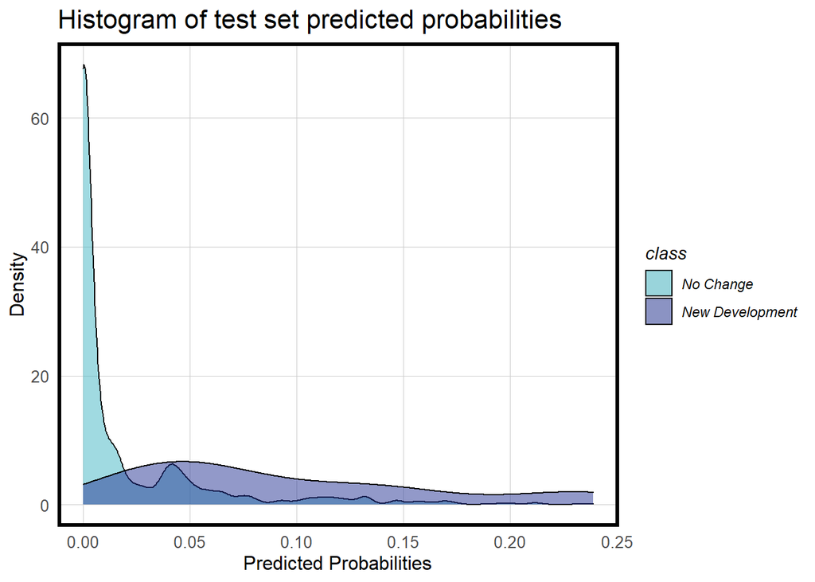

```r
testSetProbs2 <-
  data.frame(class = datTest$lc_change,
             probs = predict(Model6, datTest, type="response"))
testSetProbs <-
  data.frame(class = datTest$lc_change,
             probs = predict(Model8, datTest, type="response"))

ggplot(testSetProbs2, aes(probs)) +
  geom_density(aes(fill=class), alpha=0.5) +
  scale_fill_manual(values = palette2,
                    labels=c("No Change","New Development")) +
  labs(title = "Histogram of test set predicted probabilities",
       x="Predicted Probabilities",y="Density") +
  plotTheme()
```

## 4.3 Accuracy

```r
options(yardstick.event_first = FALSE)

testSetProbs <-
  testSetProbs %>%
  mutate(predClass_05 = as.factor(ifelse(testSetProbs$probs >= 0.05 ,1,0)),
         predClass_17 = as.factor(ifelse(testSetProbs$probs >= 0.17 ,1,0)))

testSetProbs %>%
  dplyr::select(-probs) %>%
  gather(Variable, Value, -class) %>%
  group_by(Variable) %>%
  summarize(Sensitivity = round(yardstick::sens_vec(class,factor(Value)),2),
            Specificity = round(yardstick::spec_vec(class,factor(Value)),2),
            Accuracy = round(yardstick::accuracy_vec(class,factor(Value)),2)) %>%
  kable() %>%
  kable_styling(full_width = F)
```

[output not shown]

## 4.4 Mapped Predictions

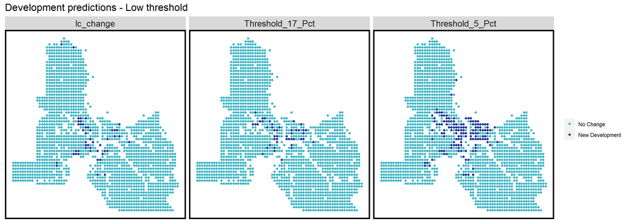

```r
predsForMap <-
  dat %>%
    mutate(probs = predict(Model8, dat, type="response") ,
           Threshold_5_Pct = as.factor(ifelse(probs >= 0.05 ,1,0)),
           Threshold_17_Pct =  as.factor(ifelse(probs >= 0.17 ,1,0))) %>%
    dplyr::select(lc_change,Threshold_5_Pct,Threshold_17_Pct) %>%
    gather(Variable,Value, -geometry) %>%
    st_cast("POLYGON")

ggplot() +
  geom_point(data=predsForMap, aes(x=xyC(predsForMap)[,1], y=xyC(predsForMap)[,2], colour=Value)) +
  facet_wrap(~Variable) +
  scale_colour_manual(values = palette2, labels=c("No Change","New Development"),
                      name="") +
  labs(title="Development predictions - Low threshold") + mapTheme()
```

## 4.5 Mapped Confusion Matrix, Tresholds

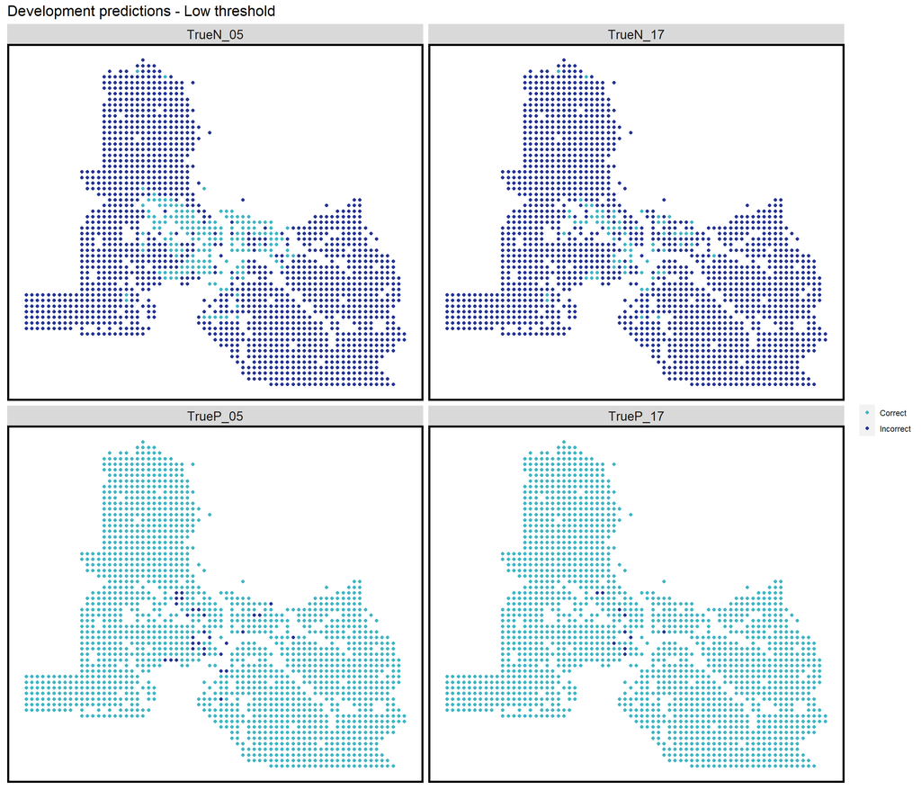

```r
ConfusionMatrix.metrics <-
  dat %>%
    mutate(probs = predict(Model9, dat, type="response") ,
           Threshold_5_Pct = as.factor(ifelse(probs >= 0.05 ,1,0)),
           Threshold_17_Pct =  as.factor(ifelse(probs >= 0.17 ,1,0))) %>%
    mutate(TrueP_05 = ifelse(lc_change  == 1 & Threshold_5_Pct == 1, 1,0),
           TrueN_05 = ifelse(lc_change  == 0 & Threshold_5_Pct == 0, 1,0),
           TrueP_17 = ifelse(lc_change  == 1 & Threshold_17_Pct == 1, 1,0),
           TrueN_17 = ifelse(lc_change  == 0 & Threshold_17_Pct == 0, 1,0)) %>%
    dplyr::select(., starts_with("True")) %>%
    gather(Variable, Value, -geometry) %>%
    st_cast("POLYGON")

ggplot(data=ConfusionMatrix.metrics) +
  geom_point(aes(x=xyC(ConfusionMatrix.metrics)[,1],
                 y=xyC(ConfusionMatrix.metrics)[,2], colour = as.factor(Value))) +
  facet_wrap(~Variable) +
  scale_colour_manual(values = palette2, labels=c("Correct","Incorrect"),
                       name="") +
  labs(title="Development predictions - Low threshold") + mapTheme()
```

## 4.6 Generalizability and Cross-Validation

```r
spatialCV <- function(dataFrame, uniqueID, dependentVariable, modelName) {

#initialize a data frame
endList <- list()

#create a list that is all the spatial group unqiue ids in the data frame (ie counties)
  uniqueID_List <- unique(dataFrame[[uniqueID]])
  x <- 1
  y <- length(uniqueID_List)

#create a counter and while it is less than the number of counties...
  while(x <= y)
  {
#call a current county
    currentUniqueID <- uniqueID_List[x]
#create a training set comprised of units not in that county and a test set of units
#that are that county
    training <- dataFrame[ which(dataFrame[[uniqueID]] != uniqueID_List[x]),]
    testing <- dataFrame[ which(dataFrame[[uniqueID]] == uniqueID_List[x]),]
#create seperate xy vectors
    trainingX <- training[ , -which(names(training) %in% c(dependentVariable))]
    testingX <- testing[ , -which(names(testing) %in% c(dependentVariable))]

    trainY <- training[[dependentVariable]]
    testY <- testing[[dependentVariable]]
#Calculate predictions on the test county as part of a data frame including the observed
#outcome and the unique county ID
   thisPrediction <-
     data.frame(class = testY,
                probs = predict(modelName, testingX, type="response"),
                county = currentUniqueID)

#Row bind the predictions to a data farme
   endList <- rbind(endList, thisPrediction)
#iterate counter
    x <- x + 1
  }
#return the final list of counties and associated predictions
  return (as.data.frame(endList))
}


spatialCV_counties <-
  spatialCV(dat,"Name","lc_change", Model8) %>%
  mutate(predClass = as.factor(ifelse(probs >= 0.17 ,1,0)))


spatialCV_metrics <-
  spatialCV_counties %>%
    group_by(county) %>%
    summarize(Observed_Change = sum(as.numeric(as.character(class))),
              Sensitivity = round(yardstick::sens_vec(class,predClass),2),
              Specificity = round(yardstick::spec_vec(class,predClass),2),
              Accuracy = round(yardstick::accuracy_vec(class,predClass),2))
spatialCV_metrics %>%
  kable() %>%
  kable_styling(full_width = F)
```

| county | Observed_Change | Sensitivity | Specificity | Accuracy |
| --- | --- | --- | --- | --- |
| Clackamas | 25 | 0.97 | 0.44 | 0.96 |
| Columbia | 2 | 1.00 | 0.00 | 0.99 |
| Multnomah | 4 | 0.91 | 0.50 | 0.90 |
| Washington | 30 | 0.95 | 0.53 | 0.93 |
| Yamhill | 7 | 1.00 | 0.14 | 0.98 |

# 5 Predicting Demand from a New Regional Rail 2021

## 5.1 2020 population

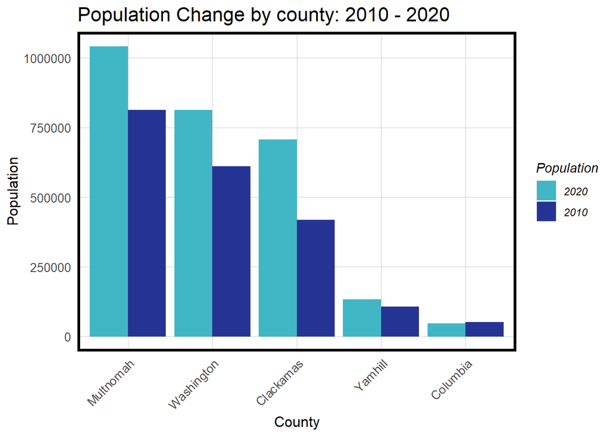

```r
dat <-
  dat %>%
  mutate(lagDevelopment = nn_function(xyC(.), xyC(filter(.,developed10 == 1)),2))

countyPopulation_2020 <-
  data.frame(
   Name =
     c("Clackamas", "Columbia", "Yamhill", "Multnomah", "Washington"),
   county_projection_2020 =
     c(418187, 52354 ,107100, 812855, 610592)) %>%
   left_join(
     dat %>%
       st_set_geometry(NULL) %>%
       group_by(Name) %>%
       summarize(county_population_2010 = round(sum(pop_2010))))

countyPopulation_2020 %>%
  gather(Variable,Value, -Name) %>%
  ggplot(aes(reorder(Name,-Value),Value)) +
  geom_bar(aes(fill=Variable), stat = "identity", position ='dodge') +
  scale_fill_manual(values = palette2,
                    labels=c("2020","2010"),
                    name="Population") +
  labs(title="Population Change by county: 2010 - 2020",
       x="County", y="Population") +
  theme(axis.text.x = element_text(angle = 45, hjust = 1)) +
  plotTheme()
```

## 5.2 2020 Demand Development

Demand tends to concentrate in the most populated areas.

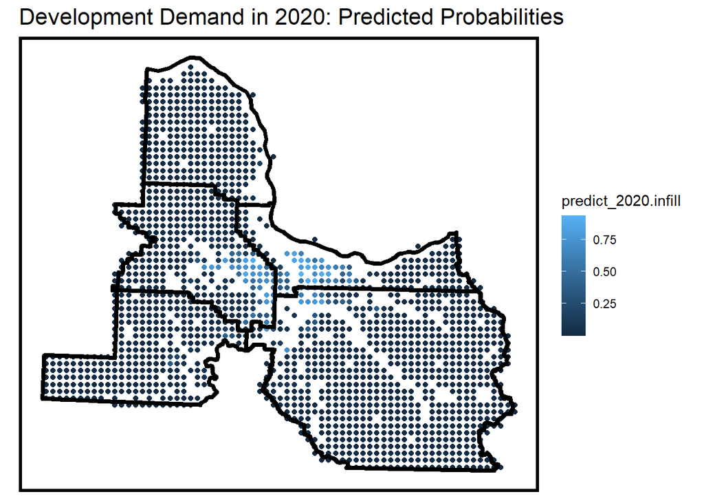

```r
dat_infill <-
  dat %>%
  #calculate population change
    left_join(countyPopulation_2020) %>%
    mutate(proportion_of_county_pop = pop_2010 / county_population_2010,
           pop_2020.infill = proportion_of_county_pop * county_projection_2020,
           pop_Change = round(pop_2020.infill - pop_2010),2) %>%
    dplyr::select(-county_projection_2020, -county_population_2010,
                  -proportion_of_county_pop, -pop_2020.infill) %>%
  #predict for 2020
    mutate(predict_2020.infill = predict(Model8,. , type="response"))

dat_infill %>%
  ggplot() +
  geom_point(aes(x=xyC(dat_infill)[,1], y=xyC(dat_infill)[,2], colour = predict_2020.infill)) +
  geom_sf(data=OregonB, fill=NA, colour="black", size=1.5) +
  labs(title= "Development Demand in 2020: Predicted Probabilities") +
  mapTheme()
```

## 5.3 Distributing Development

### 5.3.1 Land Cover Data 2011

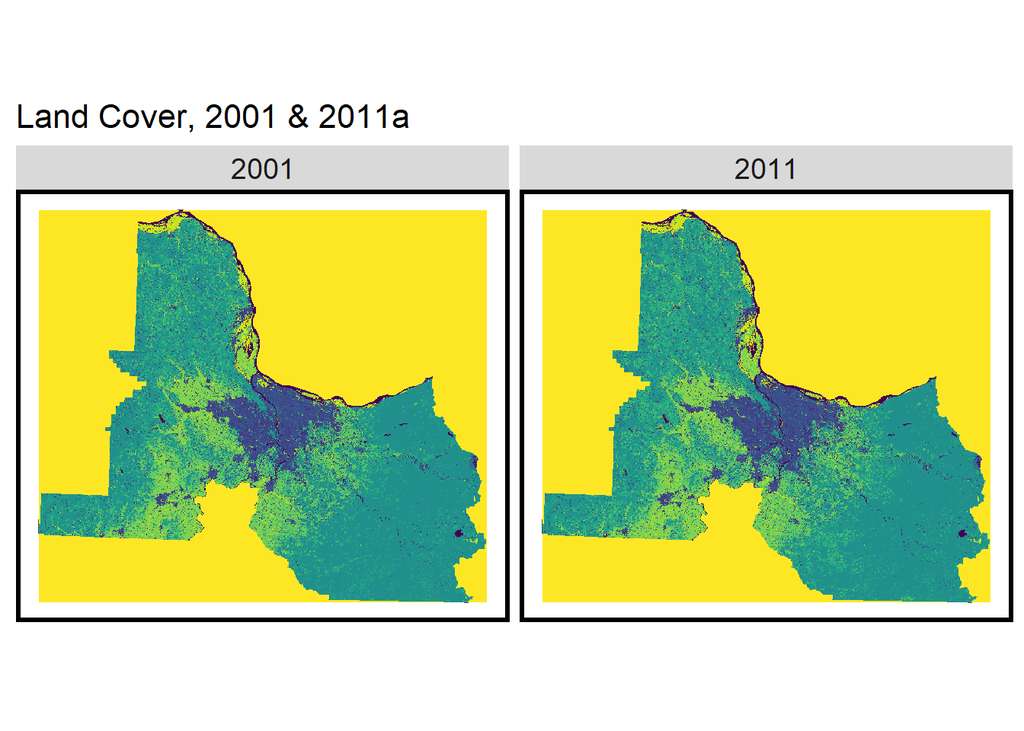

```r
developed11 <- lc_2011 == 21 | lc_2011 == 22 | lc_2011 == 23 | lc_2011 == 24
forest11 <- lc_2011 == 41 | lc_2011 == 42 | lc_2011 == 43
farm11 <- lc_2011 == 81 | lc_2011 == 82
wetlands11 <- lc_2011 == 90 | lc_2011 == 95
otherUndeveloped11 <- lc_2011 == 52 | lc_2011 == 71 | lc_2011 == 31
water11 <- lc_2011 == 11

names(developed11) <- "developed11"
names(forest11) <- "forest11"
names(farm11) <- "farm11"
names(wetlands11) <- "wetlands11"
names(otherUndeveloped11) <- "otherUndeveloped11"
names(water11) <- "water11"

ggplot() +
  geom_sf(data=OregonB) +
  geom_raster(data = rbind(rast(lc_2001) %>% mutate(label = "2001"),
                           rast(lc_2011) %>% mutate(label = "2011")) %>%
              na.omit %>% filter(value > 0),
              aes(x,y,fill=as.factor(value))) +
  facet_wrap(~label) +
  scale_fill_viridis(discrete=TRUE, name ="") +
  labs(title = "Land Cover, 2001 & 2011a") +
  mapTheme() + theme(legend.position = "none")
```

### 5.3.2 Land Cover Types

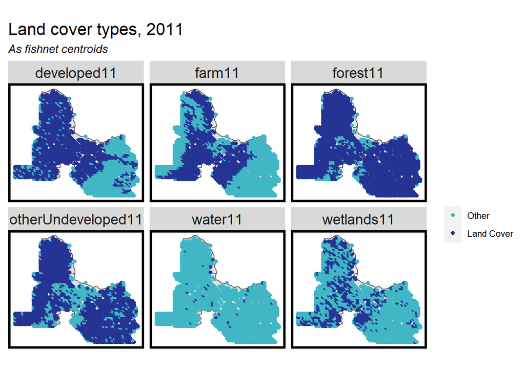

```r
theRasterList11 <- c(developed11,forest11,farm11,wetlands11,otherUndeveloped11,water11)

dat2 <-
  aggregateRaster(theRasterList11, dat) %>%
  dplyr::select(developed11,forest11,farm11,wetlands11,otherUndeveloped11,water11) %>%
  st_set_geometry(NULL) %>%
  bind_cols(.,dat) %>%
  st_sf() %>%
  st_cast("POLYGON")

dat2 %>%
  gather(var,value,developed11:water11) %>%
  st_centroid() %>%
  mutate(X = st_coordinates(.)[,1],
         Y = st_coordinates(.)[,2]) %>%
  ggplot() +
    geom_sf(data=OregonB) +
    geom_point(aes(X,Y, colour=as.factor(value))) +
    facet_wrap(~var) +
    scale_colour_manual(values = palette2,
                        labels=c("Other","Land Cover"),
                        name = "") +
    labs(title = "Land cover types, 2011",
         subtitle = "As fishnet centroids") +
   mapTheme()
```

### 5.3.3 Sensitive Land Lost

The darker points show where sensitive land - either forest or wetland - has been lost between 2001 and 2011.

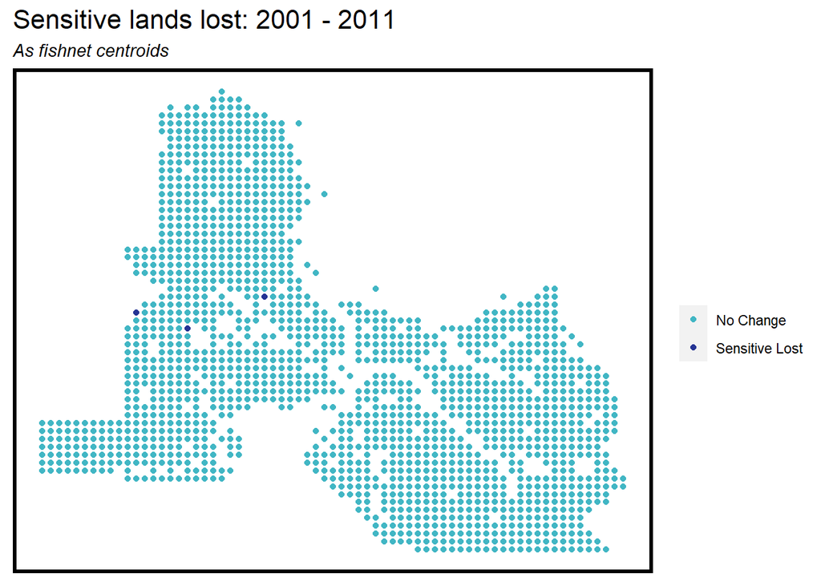

```r
dat2 <-
  dat2 %>%
   mutate(sensitive_lost11 = ifelse(forest == 1 & forest11 == 0 |
                                    wetlands == 1 & wetlands11 == 0,1,0))

ggplot() +
  geom_point(data=dat2, aes(x=xyC(dat2)[,1], y=xyC(dat2)[,2], colour=as.factor(sensitive_lost11))) +
  scale_colour_manual(values = palette2,
                      labels=c("No Change","Sensitive Lost"),
                      name = "") +
  labs(title = "Sensitive lands lost: 2001 - 2011",
       subtitle = "As fishnet centroids") +
  mapTheme()
```

### 5.3.4 Fragmentation

The darker blue represents that should not be developed, these are sensitive land cover types (forest and wetland). The urban growth boundary should include areas south of Portland.

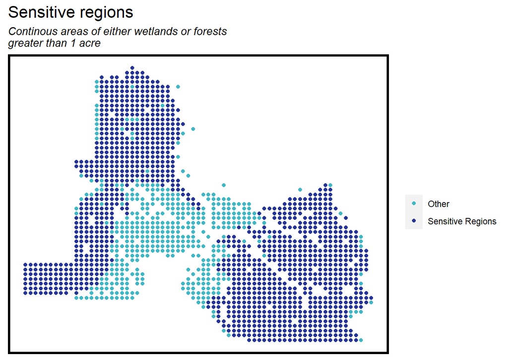

```r
sensitiveRegions <-
  clump(wetlands11 + forest11) %>%
  rasterToPolygons() %>%
  st_as_sf() %>%
  group_by(clumps) %>% summarize() %>%
    mutate(Acres = as.numeric(st_area(.) * 0.0000229568)) %>%
    filter(Acres > 3954)  %>%
  dplyr::select() %>%
  rasterize(.,emptyRaster)
sensitiveRegions[sensitiveRegions > 0] <- 1
names(sensitiveRegions) <- "sensitiveRegions"

dat2 <-
  aggregateRaster(c(sensitiveRegions), dat2) %>%
  dplyr::select(sensitiveRegions) %>%
  st_set_geometry(NULL) %>%
  bind_cols(.,dat2) %>%
  st_sf()

ggplot() +
  geom_point(data=dat2, aes(x=xyC(dat2)[,1], y=xyC(dat2)[,2], colour=as.factor(sensitiveRegions))) +
  scale_colour_manual(values = palette2,
                      labels=c("Other","Sensitive Regions"),
                      name="") +
  labs(title = "Sensitive regions",
       subtitle = "Continous areas of either wetlands or forests\ngreater than 1 acre") +
  mapTheme()
```

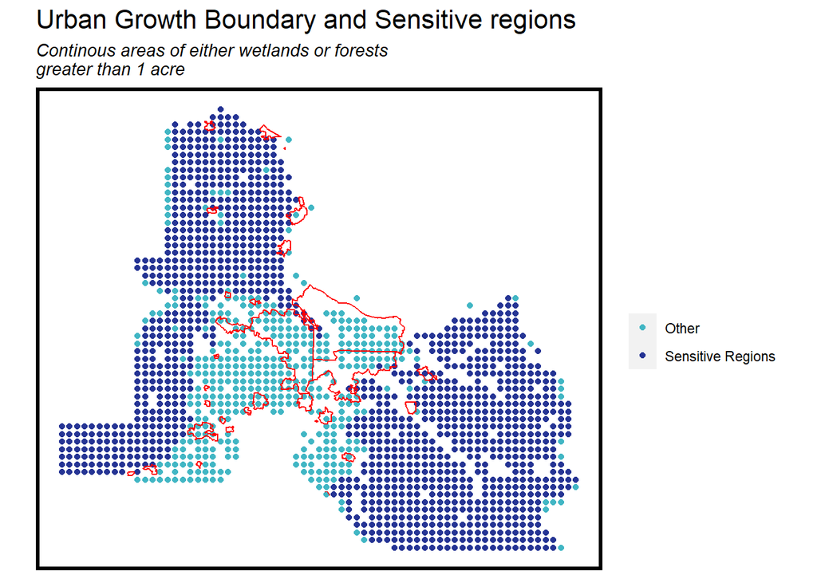

```r
ggplot() +
  geom_point(data=dat2, aes(x=xyC(dat2)[,1], y=xyC(dat2)[,2], colour=as.factor(sensitiveRegions))) +
  scale_colour_manual(values = palette2,
                      labels=c("Other","Sensitive Regions"),
                      name="") +
  labs(title = "Urban Growth Boundary and Sensitive regions",
       subtitle = "Continous areas of either wetlands or forests\ngreater than 1 acre") +
   geom_sf(data = ugb, fill = NA, colour = "red")+
  mapTheme()
```

### 5.3.5 County Summary

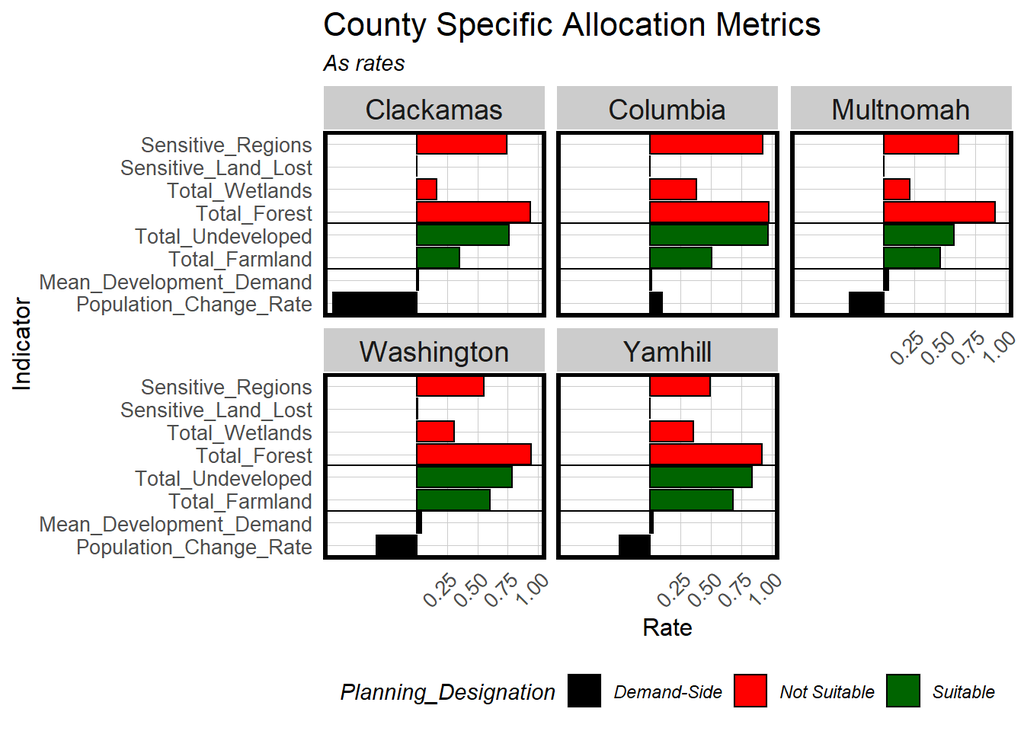

```r
county_specific_metrics <-
  dat2 %>%
  #predict development demand from our model
  mutate(Development_Demand = predict(Model10, dat2, type="response")) %>%
  #get a count count of grid cells by county which we can use to calculate rates below
  left_join(st_set_geometry(dat, NULL) %>% group_by(Name) %>% summarize(count = n())) %>%
  #calculate summary statistics by county
  group_by(Name) %>%
  summarize(Total_Farmland = sum(farm11) / max(count),
            Total_Forest = sum(forest11) / max(count),
            Total_Wetlands = sum(wetlands11) / max(count),
            Total_Undeveloped = sum(otherUndeveloped11) / max(count),
            Sensitive_Land_Lost = sum(sensitive_lost11) / max(count),
            Sensitive_Regions = sum(sensitiveRegions) / max(count),
            Mean_Development_Demand = mean(Development_Demand)) %>%
  #get population data by county
  left_join(countyPopulation_2020 %>%
            mutate(Population_Change = county_projection_2020 - county_population_2010,
                   Population_Change_Rate = Population_Change / county_projection_2020) %>%
            dplyr::select(Name,Population_Change_Rate))

county_specific_metrics %>%
  gather(Variable, Value, -Name, -geometry.1) %>%
  mutate(Variable = factor(Variable, levels=c("Population_Change_Rate","Mean_Development_Demand",
                                              "Total_Farmland","Total_Undeveloped","Total_Forest",
                                              "Total_Wetlands","Sensitive_Land_Lost","Sensitive_Regions",
                                              ordered = TRUE))) %>%
  mutate(Planning_Designation = case_when(
    Variable == "Population_Change_Rate" | Variable == "Mean_Development_Demand" ~ "Demand-Side",
    Variable == "Total_Farmland" | Variable == "Total_Undeveloped"               ~ "Suitable",
    TRUE                                                                         ~ "Not Suitable")) %>%
  ggplot(aes(x=Variable, y=Value, fill=Planning_Designation)) +
    geom_bar(stat="identity", position=position_dodge(), colour="black") +
    facet_wrap(~Name, ncol=3) +
    coord_flip() +
    scale_y_continuous(breaks = seq(.25, 1, by = .25)) +
    geom_vline(xintercept = 2.5) + geom_vline(xintercept = 4.5) +
    scale_fill_manual(values=c("black","red","darkgreen")) +
    labs(title= "County Specific Allocation Metrics", subtitle= "As rates", x="Indicator", y="Rate") +
    plotTheme() + theme(axis.text.x = element_text(angle = 45, hjust = 1), legend.position="bottom")
```

# 6 Allocation

Comparing Washington, a more developed county with a majority of undeveloped land as farm space, to Clackamas county, a less developed county with a larger variety of undeveloped land; notably forest and grasslands. The majority of Clackamas county is defined as sensitive areas. It includes Mt. Hood National Forest.

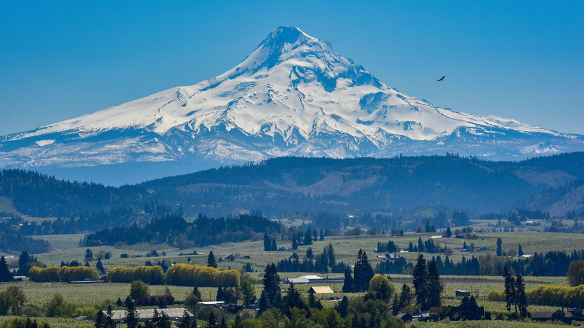

Mount Hood National Forest

## 6.1 Washington Allocation Scenario 2021

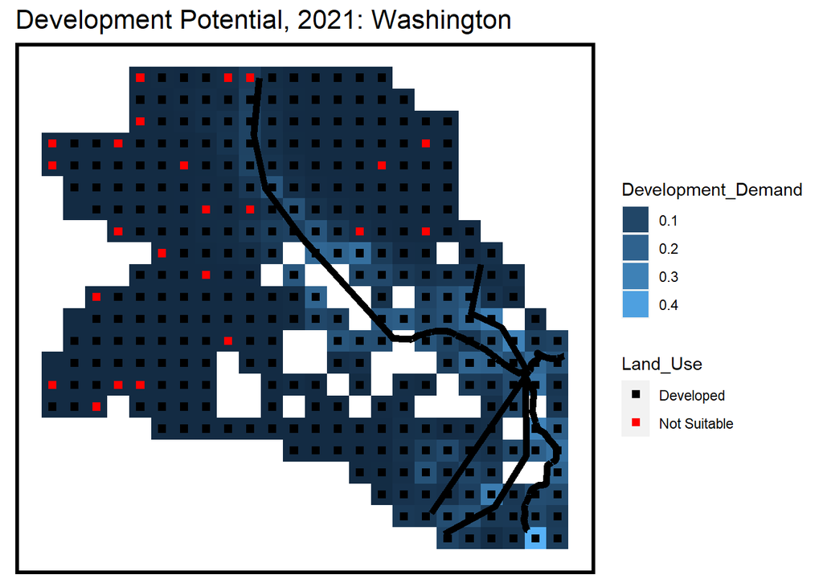

```r
washingtonC <-
  dat2 %>%
    mutate(Development_Demand = predict(Model10, dat2, type="response")) %>%
    filter(Name == "Washington")

washingtonC_landUse <- rbind(
  filter(washingtonC, forest11 == 1 | wetlands11 == 1 ) %>%
  dplyr::select() %>% mutate(Land_Use = "Not Suitable"),
  filter(washingtonC, developed11 == 1) %>%
  dplyr::select() %>% mutate(Land_Use = "Developed"))

#grid.arrange(
ggplot() +
  geom_sf(data=washingtonC, aes(fill=Development_Demand), colour=NA) +
  geom_point(data=washingtonC_landUse, aes(x=xyC(washingtonC_landUse)[,1],
                                        y=xyC(washingtonC_landUse)[,2], colour=Land_Use),
                                        shape = 15, size = 2) +
  scale_color_viridis()+
  geom_sf(data=st_intersection(fakerail,filter(studyAreaCounties, NAME=="Washington")), size=2) +
  scale_colour_manual(values = c("black","red")) +
  labs(title = "Development Potential, 2021: Washington") + mapTheme() +
  guides(fill = guide_legend(order = 1), colour = guide_legend(order = 2))#,
```

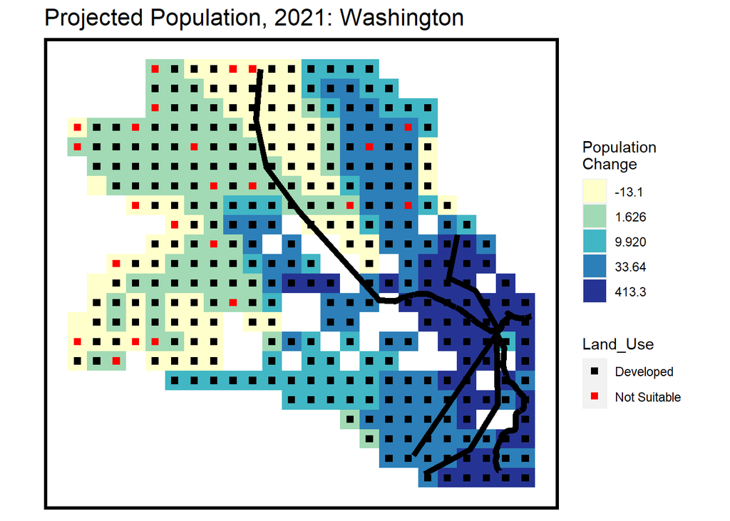

```r
ggplot() +
  geom_sf(data=washingtonC, aes(fill=factor(ntile(pop_Change,5))), colour=NA) +
  geom_point(data=washingtonC_landUse, aes(x=xyC(washingtonC_landUse)[,1],
                                        y=xyC(washingtonC_landUse)[,2], colour=Land_Use),
                                        shape = 15, size = 2) +
  geom_sf(data=st_intersection(fakerail,filter(studyAreaCounties, NAME=="Washington")), size=2) +
  scale_fill_manual(values = palette5, name="Population\nChange",
                    labels=substr(quintileBreaks(washingtonC,"pop_Change"),1,5)) +
  scale_colour_manual(values = c("black","red")) +
  labs(title = "Projected Population, 2021: Washington") + mapTheme() +
  guides(fill = guide_legend(order = 1), colour = guide_legend(order = 2))#, ncol=2)
```

## 6.2 Clackamas Allocation Scenario 2021

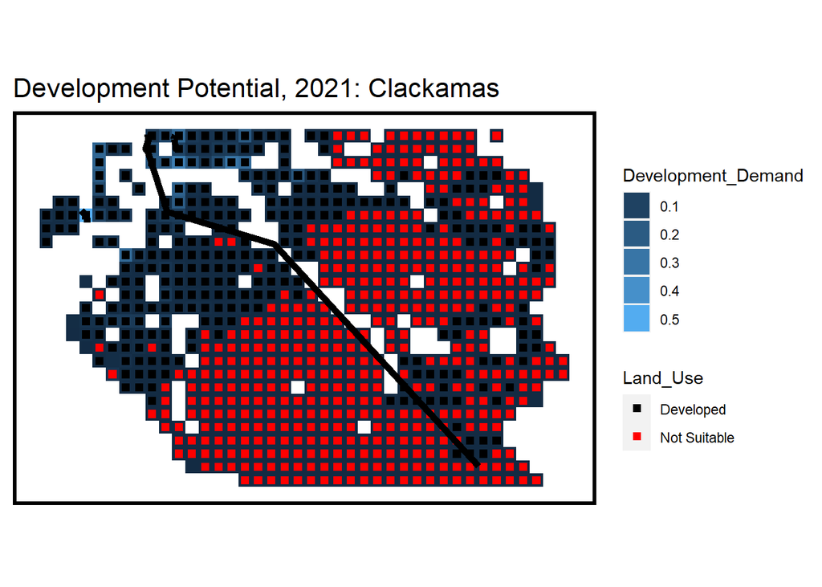

```r
ClackamasC <-
  dat2 %>%
    mutate(Development_Demand = predict(Model8, dat2, type="response")) %>%
    filter(Name == "Clackamas")

ClackamasC_landUse <- rbind(
  filter(ClackamasC, forest11 == 1 | wetlands11 == 1 ) %>%
  dplyr::select() %>% mutate(Land_Use = "Not Suitable"),
  filter(ClackamasC, developed11 == 1) %>%
  dplyr::select() %>% mutate(Land_Use = "Developed"))

#grid.arrange(
ggplot() +
  geom_sf(data=ClackamasC, aes(fill=Development_Demand), colour=NA) +
  geom_point(data=ClackamasC_landUse, aes(x=xyC(ClackamasC_landUse)[,1],
                                        y=xyC(ClackamasC_landUse)[,2], colour=Land_Use),
                                        shape = 15, size = 2) +
  scale_color_viridis()+
  geom_sf(data=st_intersection(fakerail,filter(studyAreaCounties, NAME=="Clackamas")), size=2) +
  scale_colour_manual(values = c("black","red")) +
  labs(title = "Development Potential, 2021: Clackamas") + mapTheme() +
  guides(fill = guide_legend(order = 1), colour = guide_legend(order = 2))#,
```

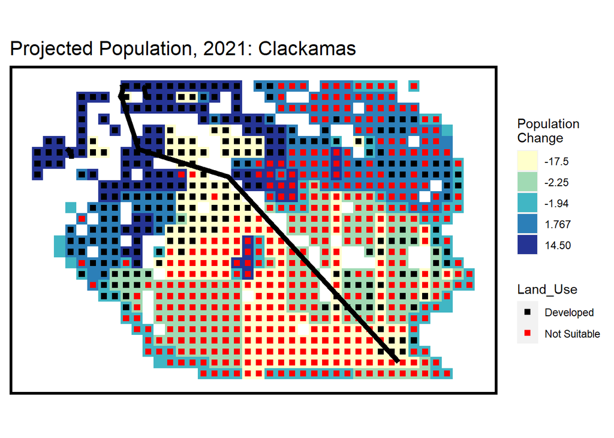

```r
ggplot() +
  geom_sf(data=ClackamasC, aes(fill=factor(ntile(pop_Change,5))), colour=NA) +
  geom_point(data=ClackamasC_landUse, aes(x=xyC(ClackamasC_landUse)[,1],
                                        y=xyC(ClackamasC_landUse)[,2], colour=Land_Use),
                                        shape = 15, size = 2) +
  geom_sf(data=st_intersection(fakerail,filter(studyAreaCounties, NAME=="Clackamas")), size=2) +
  scale_fill_manual(values = palette5, name="Population\nChange",
                    labels=substr(quintileBreaks(ClackamasC,"pop_Change"),1,5)) +
  scale_colour_manual(values = c("black","red")) +
  labs(title = "Projected Population, 2021: Clackamas") + mapTheme() +
  guides(fill = guide_legend(order = 1), colour = guide_legend(order = 2))#, ncol=2)
```

# 7 Conclusion

We believe our model is overall successful in predicting development demand and population growth. To predict development demand we looked at a variety of variables including distance to highways, land cover, urban growth boundary designation, public transportation and population. Our exploratory analysis indicates for greater development near public transportation, near highways, in urban growth boundaries and in highly populated areas. To model development, we used a binary logistical regression (binary logit) model by classifying each grid cell by either 1 or 0. 1 represents change to development land, and 0 represents everything else. The best features included population change, highway distance, in/outside UGB, and distance to railways. The McFadden R-Squared for this model was approximately 0.35. Overall, the model predicted development at 90% accuracy at a threshold 0.05. The true positive rate was 76% and the true negative rate was 90%. The model performed better identifying non-developed than developed areas. However, these areas are likely at risk for development.

Mapping our predictions, it appears that in the current scenario, development will continue to concentrate surrounding the Portland City Center within the urban growth boundary. Note that in the current scenario, transportation rail lines do not extend beyond the urban growth boundary. The counties experiencing the most population change are Multnomah, Washington and Clackamas. As expected, these counties are also where there is greater risk of development as predicted by the model. They are also the three counties that contain Portland and its environs.

We predicted development and population growth within Washington and Clackamas counties with an additional feature; distance to a fictional extension of the rail lines. We chose these two counties to look more closely at the impact of the hypothetical railway on different land types. For Washington, the land is more developed overall and has more farmland. Clackamas is less developed and contains a larger area of sensitive land, mainly forest. More than half of Clackamas is “sensitive”. The county is heavily wooded and contains a national forest. We created a development and population forecast using the model with the additional distance to fictional rail lines. Development tended to concentrate near the already-developed areas of Clackamas. The rail had a more significant impact on development in Washington County.